# Trabajo Módulo Machine Learning

## José Agustín Ianchina

### Librerías y Funciones

```python
#marca para registrar el tiempo de ejecución de todo el notebook
from time import perf_counter
start = perf_counter()
```

```python
import numpy as np
import pandas as pd
import matplotlib.pyplot as plt
import seaborn as sb
import sklearn as sk
import time
from IPython.display import Image

from sklearn.linear_model import LogisticRegression
from sklearn.datasets import make_classification
from sklearn.model_selection import train_test_split, cross_val_score
from sklearn import tree

from sklearn.feature_selection import SequentialFeatureSelector


from sklearn.inspection import permutation_importance

from sklearn.tree import DecisionTreeClassifier
from sklearn.ensemble import RandomForestClassifier, RandomForestRegressor, BaggingClassifier
from sklearn.svm import SVC
from sklearn import naive_bayes

from sklearn.feature_selection import VarianceThreshold, SelectFromModel

from sklearn.metrics import (confusion_matrix, accuracy_score, precision_score, recall_score, f1_score,
roc_auc_score, matthews_corrcoef, balanced_accuracy_score)

%matplotlib inline
```

```python
def metricas(y1, y2, clf, x_test):
    print('matriz de confusión')
    print(confusion_matrix(y1, y2))

    print('accuracy')
    print(accuracy_score(y1, y2))

    print('precision')
    print(precision_score(y1, y2, average = 'weighted'))

    print('recall')
    print(recall_score(y1, y2, average = 'weighted'))

    print('balanced accuracy')
    print(balanced_accuracy_score(y1,y2))

    print('f1')
    print(f1_score(y1, y2, average = 'weighted'))

    #false_positive_rate, recall, thresholds = roc_curve(y1, y2)

    print('AUC')
    print(roc_auc_score(y1, clf.predict_proba(x_test), multi_class = 'ovo'))

    print('MCC')
    print(matthews_corrcoef(y1,y2))
```

### Training Values Dataset

Se realiza una exploración del dataset de los valores.

```python
#carga de dataset de entrenamiento
training_values = pd.read_csv("Pump_it_Up_Data_Mining_the_Water_Table_-_Training_set_values.csv")
training_labels = pd.read_csv("Pump_it_Up_Data_Mining_the_Water_Table_-_Training_set_labels.csv")
```

```python
training_values.head()
```

|  | id | amount_tsh | date_recorded | funder | gps_height | installer | longitude | latitude | wpt_name | num_private | ... | payment_type | water_quality | quality_group | quantity | quantity_group | source | source_type | source_class | waterpoint_type | waterpoint_type_group |
| --- | --- | --- | --- | --- | --- | --- | --- | --- | --- | --- | --- | --- | --- | --- | --- | --- | --- | --- | --- | --- | --- |
| 0 | 69572 | 6000.0 | 2011-03-14 | Roman | 1390 | Roman | 34.938093 | -9.856322 | none | 0 | ... | annually | soft | good | enough | enough | spring | spring | groundwater | communal standpipe | communal standpipe |
| 1 | 8776 | 0.0 | 2013-03-06 | Grumeti | 1399 | GRUMETI | 34.698766 | -2.147466 | Zahanati | 0 | ... | never pay | soft | good | insufficient | insufficient | rainwater harvesting | rainwater harvesting | surface | communal standpipe | communal standpipe |
| 2 | 34310 | 25.0 | 2013-02-25 | Lottery Club | 686 | World vision | 37.460664 | -3.821329 | Kwa Mahundi | 0 | ... | per bucket | soft | good | enough | enough | dam | dam | surface | communal standpipe multiple | communal standpipe |
| 3 | 67743 | 0.0 | 2013-01-28 | Unicef | 263 | UNICEF | 38.486161 | -11.155298 | Zahanati Ya Nanyumbu | 0 | ... | never pay | soft | good | dry | dry | machine dbh | borehole | groundwater | communal standpipe multiple | communal standpipe |
| 4 | 19728 | 0.0 | 2011-07-13 | Action In A | 0 | Artisan | 31.130847 | -1.825359 | Shuleni | 0 | ... | never pay | soft | good | seasonal | seasonal | rainwater harvesting | rainwater harvesting | surface | communal standpipe | communal standpipe |

5 rows × 40 columns

```python
training_values.info()
```

```
<class 'pandas.core.frame.DataFrame'>
RangeIndex: 59400 entries, 0 to 59399
Data columns (total 40 columns):
 #   Column                 Non-Null Count  Dtype
---  ------                 --------------  -----
 0   id                     59400 non-null  int64
 1   amount_tsh             59400 non-null  float64
 2   date_recorded          59400 non-null  object
 3   funder                 55765 non-null  object
 4   gps_height             59400 non-null  int64
 5   installer              55745 non-null  object
 6   longitude              59400 non-null  float64
 7   latitude               59400 non-null  float64
 8   wpt_name               59400 non-null  object
 9   num_private            59400 non-null  int64
```

[output cut: 32 more lines]

```python
training_values.describe()
```

|  | id | amount_tsh | gps_height | longitude | latitude | num_private | region_code | district_code | population | construction_year |
| --- | --- | --- | --- | --- | --- | --- | --- | --- | --- | --- |
| count | 59400.000000 | 59400.000000 | 59400.000000 | 59400.000000 | 5.940000e+04 | 59400.000000 | 59400.000000 | 59400.000000 | 59400.000000 | 59400.000000 |
| mean | 37115.131768 | 317.650385 | 668.297239 | 34.077427 | -5.706033e+00 | 0.474141 | 15.297003 | 5.629747 | 179.909983 | 1300.652475 |
| std | 21453.128371 | 2997.574558 | 693.116350 | 6.567432 | 2.946019e+00 | 12.236230 | 17.587406 | 9.633649 | 471.482176 | 951.620547 |
| min | 0.000000 | 0.000000 | -90.000000 | 0.000000 | -1.164944e+01 | 0.000000 | 1.000000 | 0.000000 | 0.000000 | 0.000000 |
| 25% | 18519.750000 | 0.000000 | 0.000000 | 33.090347 | -8.540621e+00 | 0.000000 | 5.000000 | 2.000000 | 0.000000 | 0.000000 |
| 50% | 37061.500000 | 0.000000 | 369.000000 | 34.908743 | -5.021597e+00 | 0.000000 | 12.000000 | 3.000000 | 25.000000 | 1986.000000 |
| 75% | 55656.500000 | 20.000000 | 1319.250000 | 37.178387 | -3.326156e+00 | 0.000000 | 17.000000 | 5.000000 | 215.000000 | 2004.000000 |
| max | 74247.000000 | 350000.000000 | 2770.000000 | 40.345193 | -2.000000e-08 | 1776.000000 | 99.000000 | 80.000000 | 30500.000000 | 2013.000000 |

#### Missing values

```python
#análisis de valores nulos. Se computa la proporción de faltantes.
for i,j in enumerate(training_values.columns):
    n = len(training_values)
    a = training_values[j].isna().sum()
    v = len(training_values[j].value_counts())
    if a/n>0:
        print(i,j,round(a/n,3),v)
```

```
3 funder 0.061 1897
5 installer 0.062 2145
11 subvillage 0.006 19287
18 public_meeting 0.056 2
20 scheme_management 0.065 12
21 scheme_name 0.474 2696
22 permit 0.051 2
```

```python
training_values['public_meeting'].unique()
```

```
array([True, nan, False], dtype=object)
```

```python
training_values['scheme_management'].unique()
```

```
array(['VWC', 'Other', nan, 'Private operator', 'WUG', 'Water Board',
       'WUA', 'Water authority', 'Company', 'Parastatal', 'Trust', 'SWC',
       'None'], dtype=object)
```

```python
training_values['permit'].unique()
```

```
array([False, True, nan], dtype=object)
```

```python
impute = ['funder', 'installer', 'subvillage',
          'public_meeting', 'scheme_management', 'permit']
```

```python
for i in impute:
    print(i,len(training_values[i].value_counts()))
```

```
funder 1897
installer 2145
subvillage 19287
public_meeting 2
scheme_management 12
permit 2
```

```python
for i,j in enumerate(training_values.columns):
    if len(training_values)==(training_values[j].isna().sum()):
        print(i,j)
```

```python
#total de rows que tienen al menos 1 missing en algún campo
training_values[training_values.isna().any(axis=1)].shape
```

```
(31587, 40)
```

###### Se eliminará scheme_name ya que la proporción de missing es +47%.

```python
df = training_values.copy()
df.drop(labels = 'scheme_name', axis =1, inplace = True)
len(df.columns)
```

```
39
```

```python
#se verifica la mejora en cuanto a filas con valores missing. (De 31k a 11k)
df[df.isna().any(axis=1)].shape
```

```
(11112, 39)
```

### Exploración de las variables

```python
#vemos cuántos valores únicos tiene cada variable, y ordenamos en ascendente.
u = list()
n = list()
for i in df:
    l = len(df[i].value_counts())
    u.append(l)
    n.append(i)
unique = {'col':n, 'count':u}
unique = pd.DataFrame(unique, index = unique['col'])
unique.sort_values(by = 'count')
```

|  | col | count |
| --- | --- | --- |
| recorded_by | recorded_by | 1 |
| permit | permit | 2 |
| public_meeting | public_meeting | 2 |
| source_class | source_class | 3 |
| quantity_group | quantity_group | 5 |
| quantity | quantity | 5 |
| management_group | management_group | 5 |
| quality_group | quality_group | 6 |
| waterpoint_type_group | waterpoint_type_group | 6 |
| source_type | source_type | 7 |
| payment_type | payment_type | 7 |
| payment | payment | 7 |
| waterpoint_type | waterpoint_type | 7 |
| extraction_type_class | extraction_type_class | 7 |
| water_quality | water_quality | 8 |
| basin | basin | 9 |
| source | source | 10 |
| scheme_management | scheme_management | 12 |
| management | management | 12 |
| extraction_type_group | extraction_type_group | 13 |
| extraction_type | extraction_type | 18 |
| district_code | district_code | 20 |
| region | region | 21 |
| region_code | region_code | 27 |
| construction_year | construction_year | 55 |
| num_private | num_private | 65 |
| amount_tsh | amount_tsh | 98 |
| lga | lga | 125 |
| date_recorded | date_recorded | 356 |
| population | population | 1049 |
| funder | funder | 1897 |
| ward | ward | 2092 |
| installer | installer | 2145 |
| gps_height | gps_height | 2428 |
| subvillage | subvillage | 19287 |
| wpt_name | wpt_name | 37400 |
| longitude | longitude | 57516 |
| latitude | latitude | 57517 |
| id | id | 59400 |

```python
#ordenamos el dataset anterior alfabéticamente.
unique.sort_values(by = 'col')
```

|  | col | count |
| --- | --- | --- |
| amount_tsh | amount_tsh | 98 |
| basin | basin | 9 |
| construction_year | construction_year | 55 |
| date_recorded | date_recorded | 356 |
| district_code | district_code | 20 |
| extraction_type | extraction_type | 18 |
| extraction_type_class | extraction_type_class | 7 |
| extraction_type_group | extraction_type_group | 13 |
| funder | funder | 1897 |
| gps_height | gps_height | 2428 |
| id | id | 59400 |
| installer | installer | 2145 |
| latitude | latitude | 57517 |
| lga | lga | 125 |
| longitude | longitude | 57516 |
| management | management | 12 |
| management_group | management_group | 5 |
| num_private | num_private | 65 |
| payment | payment | 7 |
| payment_type | payment_type | 7 |
| permit | permit | 2 |
| population | population | 1049 |
| public_meeting | public_meeting | 2 |
| quality_group | quality_group | 6 |
| quantity | quantity | 5 |
| quantity_group | quantity_group | 5 |
| recorded_by | recorded_by | 1 |
| region | region | 21 |
| region_code | region_code | 27 |
| scheme_management | scheme_management | 12 |
| source | source | 10 |
| source_class | source_class | 3 |
| source_type | source_type | 7 |
| subvillage | subvillage | 19287 |
| ward | ward | 2092 |
| water_quality | water_quality | 8 |
| waterpoint_type | waterpoint_type | 7 |
| waterpoint_type_group | waterpoint_type_group | 6 |
| wpt_name | wpt_name | 37400 |

###### Análisis de contenido de variables

Se observan valores únicos y se realizan countplots para comparar variables cuyos nombres son similares.

```python
df['payment_type'].unique()
```

```
array(['annually', 'never pay', 'per bucket', 'unknown', 'on failure',
       'other', 'monthly'], dtype=object)
```

```python
df['payment'].unique()
```

```
array(['pay annually', 'never pay', 'pay per bucket', 'unknown',
       'pay when scheme fails', 'other', 'pay monthly'], dtype=object)
```

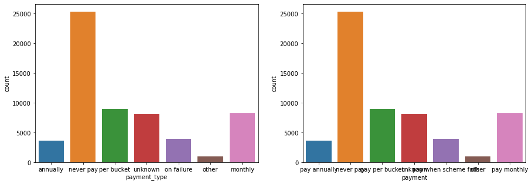

```python
plt.figure(figsize = (15,5))
plt.subplot(1,2,1)
sb.countplot(data = df, x = 'payment_type');
#plt.title('APR distribution for each Income Range');

plt.subplot(1,2,2)
sb.countplot(data = df, x = 'payment');
#plt.title('APR media for each Income Range');
```

```python
df['scheme_management'].unique()
```

```
array(['VWC', 'Other', nan, 'Private operator', 'WUG', 'Water Board',
       'WUA', 'Water authority', 'Company', 'Parastatal', 'Trust', 'SWC',
       'None'], dtype=object)
```

```python
df['management'].unique()
```

```
array(['vwc', 'wug', 'other', 'private operator', 'water board', 'wua',
       'company', 'water authority', 'parastatal', 'unknown',
       'other - school', 'trust'], dtype=object)
```

```python
df['management_group'].unique()
```

```
array(['user-group', 'other', 'commercial', 'parastatal', 'unknown'],
      dtype=object)
```

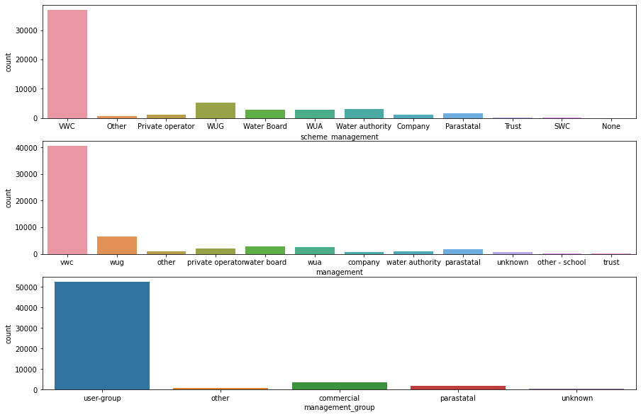

```python
plt.figure(figsize = (15,10))
plt.subplot(3,1,1)
sb.countplot(data = df, x = 'scheme_management');
#plt.title('APR distribution for each Income Range');

plt.subplot(3,1,2)
sb.countplot(data = df, x = 'management');
#plt.title('APR media for each Income Range');

plt.subplot(3,1,3)
sb.countplot(data = df, x = 'management_group');
```

```python
df['extraction_type_group'].unique()
```

```
array(['gravity', 'submersible', 'swn 80', 'nira/tanira', 'india mark ii',
       'other', 'mono', 'wind-powered', 'afridev', 'rope pump',
       'india mark iii', 'other handpump', 'other motorpump'],
      dtype=object)
```

```python
df['extraction_type'].unique()
```

```
array(['gravity', 'submersible', 'swn 80', 'nira/tanira', 'india mark ii',
       'other', 'ksb', 'mono', 'windmill', 'afridev', 'other - rope pump',
       'india mark iii', 'other - swn 81', 'other - play pump', 'cemo',
       'climax', 'walimi', 'other - mkulima/shinyanga'], dtype=object)
```

```python
df['extraction_type_class'].unique()
```

```
array(['gravity', 'submersible', 'handpump', 'other', 'motorpump',
       'wind-powered', 'rope pump'], dtype=object)
```

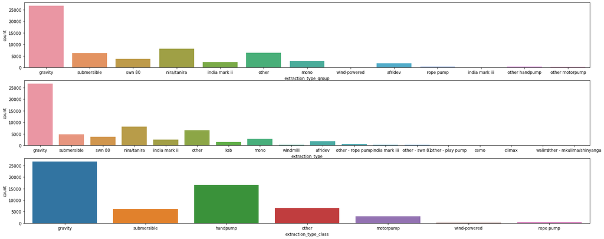

```python
plt.figure(figsize = (25,10))
plt.subplot(3,1,1)
sb.countplot(data = df, x = 'extraction_type_group');
#plt.title('APR distribution for each Income Range');

plt.subplot(3,1,2)
sb.countplot(data = df, x = 'extraction_type');
#plt.title('APR media for each Income Range');

plt.subplot(3,1,3)
sb.countplot(data = df, x = 'extraction_type_class');
#plt.title('APR media for each Income Range');
```

```python
df['quantity_group'].unique()
```

```
array(['enough', 'insufficient', 'dry', 'seasonal', 'unknown'],
      dtype=object)
```

```python
df['quantity'].unique()
```

```
array(['enough', 'insufficient', 'dry', 'seasonal', 'unknown'],
      dtype=object)
```

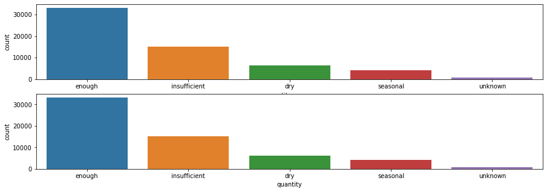

```python
plt.figure(figsize = (15,5))
plt.subplot(2,1,1)
sb.countplot(data = df, x = 'quantity_group');
#plt.title('APR distribution for each Income Range');

plt.subplot(2,1,2)
sb.countplot(data = df, x = 'quantity');
#plt.title('APR media for each Income Range');
```

```python
df['waterpoint_type'].unique()
```

```
array(['communal standpipe', 'communal standpipe multiple', 'hand pump',
       'other', 'improved spring', 'cattle trough', 'dam'], dtype=object)
```

```python
df['waterpoint_type_group'].unique()
```

```
array(['communal standpipe', 'hand pump', 'other', 'improved spring',
       'cattle trough', 'dam'], dtype=object)
```

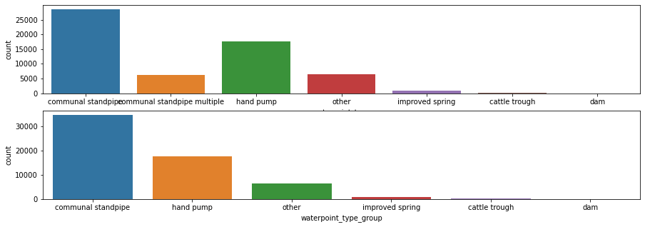

```python
plt.figure(figsize = (15,5))
plt.subplot(2,1,1)
sb.countplot(data = df, x = 'waterpoint_type');
#plt.title('APR distribution for each Income Range');

plt.subplot(2,1,2)
sb.countplot(data = df, x = 'waterpoint_type_group');
#plt.title('APR media for each Income Range');
```

```python
df['region'].unique()
```

```
array(['Iringa', 'Mara', 'Manyara', 'Mtwara', 'Kagera', 'Tanga',
       'Shinyanga', 'Tabora', 'Pwani', 'Ruvuma', 'Kilimanjaro', 'Rukwa',
       'Mwanza', 'Kigoma', 'Lindi', 'Dodoma', 'Arusha', 'Mbeya',
       'Singida', 'Morogoro', 'Dar es Salaam'], dtype=object)
```

```python
df['region_code'].unique()
```

```
array([11, 20, 21, 90, 18,  4, 17, 14, 60, 10,  3, 15, 19, 16, 80,  1,  6,
        2, 12, 13,  5,  7, 99, 24,  9,  8, 40])
```

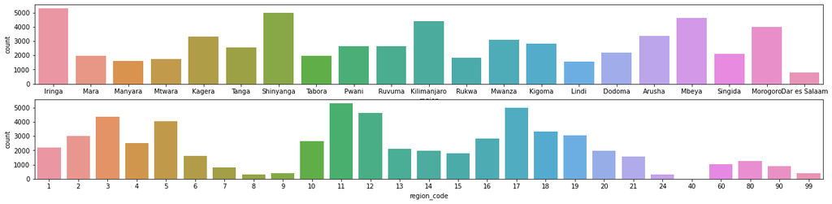

```python
plt.figure(figsize = (22,5))
plt.subplot(2,1,1)
sb.countplot(data = df, x = 'region');
#plt.title('APR distribution for each Income Range');

plt.subplot(2,1,2)
sb.countplot(data = df, x = 'region_code');
#plt.title('APR media for each Income Range');
```

```python
df['source'].unique()
```

```
array(['spring', 'rainwater harvesting', 'dam', 'machine dbh', 'other',
       'shallow well', 'river', 'hand dtw', 'lake', 'unknown'],
      dtype=object)
```

```python
df['source_class'].unique()
```

```
array(['groundwater', 'surface', 'unknown'], dtype=object)
```

```python
df['source_type'].unique()
```

```
array(['spring', 'rainwater harvesting', 'dam', 'borehole', 'other',
       'shallow well', 'river/lake'], dtype=object)
```

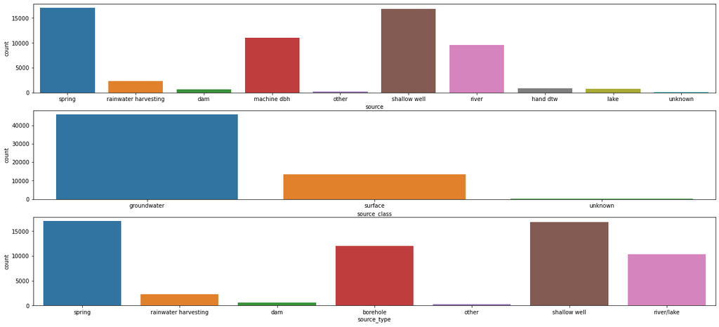

```python
plt.figure(figsize = (22,10))
plt.subplot(3,1,1)
sb.countplot(data = df, x = 'source');
#plt.title('APR distribution for each Income Range');

plt.subplot(3,1,2)
sb.countplot(data = df, x = 'source_class');
#plt.title('APR media for each Income Range');

plt.subplot(3,1,3)
sb.countplot(data = df, x = 'source_type');
#plt.title('APR media for each Income Range');
```

```python
df['water_quality'].unique()
```

```
array(['soft', 'salty', 'milky', 'unknown', 'fluoride', 'coloured',
       'salty abandoned', 'fluoride abandoned'], dtype=object)
```

```python
df['quality_group'].unique()
```

```
array(['good', 'salty', 'milky', 'unknown', 'fluoride', 'colored'],
      dtype=object)
```

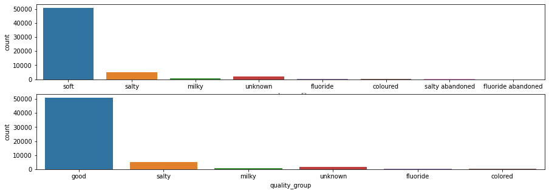

```python
plt.figure(figsize = (15,5))
plt.subplot(2,1,1)
sb.countplot(data = df, x = 'water_quality');
#plt.title('APR distribution for each Income Range');

plt.subplot(2,1,2)
sb.countplot(data = df, x = 'quality_group');
#plt.title('APR media for each Income Range');
```

###### Se eliminan algunas variables, basándose en lo observado anteriormente:

```python
#eliminación de columnas
df.drop(labels = ['recorded_by','payment_type','extraction_type_group','extraction_type_group'
                 ,'quantity_group', 'waterpoint_type_group', 'latitude',
                 'longitude', 'subvillage','ward','management','region_code',
                  'wpt_name','water_quality', 'date_recorded']
        , axis =1, inplace = True)
len(df.columns)
```

```
25
```

```python
#verificación de la eliminación de las columnas
df.columns
```

```
Index(['id', 'amount_tsh', 'funder', 'gps_height', 'installer', 'num_private',
       'basin', 'region', 'district_code', 'lga', 'population',
       'public_meeting', 'scheme_management', 'permit', 'construction_year',
       'extraction_type', 'extraction_type_class', 'management_group',
       'payment', 'quality_group', 'quantity', 'source', 'source_type',
       'source_class', 'waterpoint_type'],
      dtype='object')
```

### Imputación Missing

###### Se creará una nueva categoría missing_value. De esta forma se pretende:

- por un lado capturar patrones de información faltante.
- no imputar con una categoría pre-existente evita asumir algo en particular en cuanto los valores faltantes.

```python
df.isna().sum()
```

```
id                          0
amount_tsh                  0
funder                   3635
gps_height                  0
installer                3655
num_private                 0
basin                       0
region                      0
district_code               0
lga                         0
population                  0
public_meeting           3334
scheme_management        3877
permit                   3056
construction_year           0
extraction_type             0
extraction_type_class       0
management_group            0
payment                     0
quality_group               0
quantity                    0
source                      0
source_type                 0
source_class                0
waterpoint_type             0
dtype: int64
```

```python
df.fillna('missing_value', inplace = True)
```

### Training Labels

###### Exploración

```python
training_labels.info()
```

```
<class 'pandas.core.frame.DataFrame'>
RangeIndex: 59400 entries, 0 to 59399
Data columns (total 2 columns):
 #   Column        Non-Null Count  Dtype
---  ------        --------------  -----
 0   id            59400 non-null  int64
 1   status_group  59400 non-null  object
dtypes: int64(1), object(1)
memory usage: 928.2+ KB
```

```python
training_labels.head()
```

|  | id | status_group |
| --- | --- | --- |
| 0 | 69572 | functional |
| 1 | 8776 | functional |
| 2 | 34310 | functional |
| 3 | 67743 | non functional |
| 4 | 19728 | functional |

```python
training_labels.status_group.unique()
```

```
array(['functional', 'non functional', 'functional needs repair'],
      dtype=object)
```

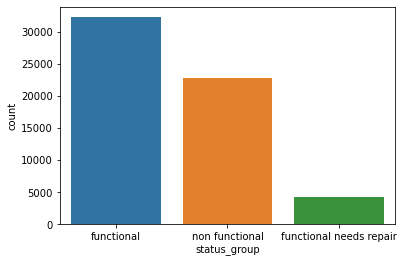

```python
sb.countplot(x = 'status_group', data = training_labels)
```

```python
training_labels.columns
```

```
Index(['id', 'status_group'], dtype='object')
```

### Construcción dataframe "df"

###### Se realiza un merge de training_values con training_labels con fines prácticos de tener variables predictoras y target en un dataframe.

```python
#unión de values con labels.
df = df.merge(training_labels, on = 'id', how = 'inner')
```

```python
# verificación de nulos.
df[df.isna().any(axis=1)].shape
```

```
(0, 26)
```

```python
#exploración de valores únicos en variable target.
df['status_group'].unique()
```

```
array(['functional', 'non functional', 'functional needs repair'],
      dtype=object)
```

### Codificación

###### Para realizar la clasificación multiclase a través de scikit-learn se necesita transformar todas las variables categóricas en numéricas.

- transformar variable target en 1,2,3
- transformar variables predictivas según lo siguiente:
  - la categoría de la columna se reemplaza por su probabilidad con respecto a la variable Target.

```python
#transformar variable target en 1,2,3
r = {'functional':1, 'non functional':2, 'functional needs repair':3}
df['status_group'].replace(to_replace = r, inplace = True)
```

```python
#la categoría de la columna se reemplaza por su probabilidad con respecto a la variable Target
encoded_dict = {} #se almacena la codificación en un diccionario.
for i in df.select_dtypes('object').columns:
    encoded_mean_dict = df.groupby([i])['status_group'].mean().to_dict()
    df[i] = df[i].map(encoded_mean_dict)
    encoded_dict[i] = encoded_mean_dict
df.head()
```

|  | id | amount_tsh | funder | gps_height | installer | num_private | basin | region | district_code | lga | ... | extraction_type_class | management_group | payment | quality_group | quantity | source | source_type | source_class | waterpoint_type | status_group |
| --- | --- | --- | --- | --- | --- | --- | --- | --- | --- | --- | --- | --- | --- | --- | --- | --- | --- | --- | --- | --- | --- |
| 0 | 69572 | 6000.0 | 1.210909 | 1390 | 1.468085 | 0 | 1.395477 | 1.241028 | 5 | 1.244681 | ... | 1.501606 | 1.536178 | 1.315486 | 1.510882 | 1.419996 | 1.452676 | 1.452676 | 1.517535 | 1.457752 | 1 |
| 1 | 8776 | 0.0 | 1.188679 | 1399 | 1.153846 | 0 | 1.598849 | 1.580498 | 2 | 1.445531 | ... | 1.501606 | 1.536178 | 1.626322 | 1.510882 | 1.572609 | 1.532898 | 1.532898 | 1.572704 | 1.457752 | 1 |
| 2 | 34310 | 25.0 | 1.000000 | 686 | 1.477941 | 0 | 1.452461 | 1.437145 | 4 | 1.435065 | ... | 1.501606 | 1.536178 | 1.367724 | 1.510882 | 1.419996 | 1.650915 | 1.650915 | 1.572704 | 1.739964 | 1 |
| 3 | 67743 | 0.0 | 1.526017 | 263 | 1.504505 | 0 | 1.700868 | 1.769942 | 63 | 1.734177 | ... | 1.502185 | 1.536178 | 1.626322 | 1.510882 | 1.980788 | 1.554763 | 1.547159 | 1.517535 | 1.739964 | 2 |
| 4 | 19728 | 0.0 | 1.000000 | 0 | 1.488889 | 0 | 1.598849 | 1.570869 | 1 | 1.527886 | ... | 1.501606 | 1.499470 | 1.626322 | 1.510882 | 1.528642 | 1.532898 | 1.532898 | 1.572704 | 1.457752 | 1 |

5 rows × 26 columns

```python
df.info()
```

```
<class 'pandas.core.frame.DataFrame'>
Int64Index: 59400 entries, 0 to 59399
Data columns (total 26 columns):
 #   Column                 Non-Null Count  Dtype
---  ------                 --------------  -----
 0   id                     59400 non-null  int64
 1   amount_tsh             59400 non-null  float64
 2   funder                 59400 non-null  float64
 3   gps_height             59400 non-null  int64
 4   installer              59400 non-null  float64
 5   num_private            59400 non-null  int64
 6   basin                  59400 non-null  float64
 7   region                 59400 non-null  float64
 8   district_code          59400 non-null  int64
 9   lga                    59400 non-null  float64
```

[output cut: 18 more lines]

```python
encoded_dict.keys()
```

```
dict_keys(['funder', 'installer', 'basin', 'region', 'lga', 'public_meeting', 'scheme_management', 'permit', 'extraction_type', 'extraction_type_class', 'management_group', 'payment', 'quality_group', 'quantity', 'source', 'source_type', 'source_class', 'waterpoint_type'])
```

```python
#celda auxiliar
'missing_value' in encoded_dict['funder'], 'missing_value' in encoded_dict['installer']
```

```
(True, True)
```

### Test Set

###### Se realizan las mismas operaciones que se realizan sobre el dataframe de training:

- eliminación de columnas
- creación de categoría "missing_value"
- codificación de cada categoría según su probabilidad vs target

```python
test_set = pd.read_csv("Pump_it_Up_Data_Mining_the_Water_Table_-_Test_set_values.csv")
test_set.head()
```

|  | id | amount_tsh | date_recorded | funder | gps_height | installer | longitude | latitude | wpt_name | num_private | ... | payment_type | water_quality | quality_group | quantity | quantity_group | source | source_type | source_class | waterpoint_type | waterpoint_type_group |
| --- | --- | --- | --- | --- | --- | --- | --- | --- | --- | --- | --- | --- | --- | --- | --- | --- | --- | --- | --- | --- | --- |
| 0 | 50785 | 0.0 | 2013-02-04 | Dmdd | 1996 | DMDD | 35.290799 | -4.059696 | Dinamu Secondary School | 0 | ... | never pay | soft | good | seasonal | seasonal | rainwater harvesting | rainwater harvesting | surface | other | other |
| 1 | 51630 | 0.0 | 2013-02-04 | Government Of Tanzania | 1569 | DWE | 36.656709 | -3.309214 | Kimnyak | 0 | ... | never pay | soft | good | insufficient | insufficient | spring | spring | groundwater | communal standpipe | communal standpipe |
| 2 | 17168 | 0.0 | 2013-02-01 | NaN | 1567 | NaN | 34.767863 | -5.004344 | Puma Secondary | 0 | ... | never pay | soft | good | insufficient | insufficient | rainwater harvesting | rainwater harvesting | surface | other | other |
| 3 | 45559 | 0.0 | 2013-01-22 | Finn Water | 267 | FINN WATER | 38.058046 | -9.418672 | Kwa Mzee Pange | 0 | ... | unknown | soft | good | dry | dry | shallow well | shallow well | groundwater | other | other |
| 4 | 49871 | 500.0 | 2013-03-27 | Bruder | 1260 | BRUDER | 35.006123 | -10.950412 | Kwa Mzee Turuka | 0 | ... | monthly | soft | good | enough | enough | spring | spring | groundwater | communal standpipe | communal standpipe |

5 rows × 40 columns

```python
test_set.columns
```

```
Index(['id', 'amount_tsh', 'date_recorded', 'funder', 'gps_height',
       'installer', 'longitude', 'latitude', 'wpt_name', 'num_private',
       'basin', 'subvillage', 'region', 'region_code', 'district_code', 'lga',
       'ward', 'population', 'public_meeting', 'recorded_by',
       'scheme_management', 'scheme_name', 'permit', 'construction_year',
       'extraction_type', 'extraction_type_group', 'extraction_type_class',
       'management', 'management_group', 'payment', 'payment_type',
       'water_quality', 'quality_group', 'quantity', 'quantity_group',
       'source', 'source_type', 'source_class', 'waterpoint_type',
       'waterpoint_type_group'],
      dtype='object')
```

```python
#eliminación de columnas
test_set.drop(labels = ['recorded_by','payment_type','extraction_type_group','extraction_type_group'
                 ,'quantity_group', 'waterpoint_type_group', 'latitude',
                 'longitude', 'subvillage','ward','management','region_code',
                  'wpt_name','water_quality', 'date_recorded','scheme_name']
        , axis =1, inplace = True)
len(test_set.columns)
```

```
25
```

```python
#creación categoría "missing_value"
test_set.fillna('missing_value', inplace = True)
```

```python
#codificación de categorías
test_set.replace(to_replace = encoded_dict, inplace = True)
test_set.head()
```

|  | id | amount_tsh | funder | gps_height | installer | num_private | basin | region | district_code | lga | ... | extraction_type | extraction_type_class | management_group | payment | quality_group | quantity | source | source_type | source_class | waterpoint_type |
| --- | --- | --- | --- | --- | --- | --- | --- | --- | --- | --- | --- | --- | --- | --- | --- | --- | --- | --- | --- | --- | --- |
| 0 | 50785 | 0.0 | 1.177419 | 1996 | 1.337079 | 0 | 1.495825 | 1.437145 | 3 | 1.390572 | ... | 1.872006 | 1.872006 | 1.542421 | 1.626322 | 1.510882 | 1.528642 | 1.532898 | 1.532898 | 1.572704 | 1.914263 |
| 1 | 51630 | 0.0 | 1.667657 | 1569 | 1.551144 | 0 | 1.452461 | 1.367463 | 2 | 1.339457 | ... | 1.501606 | 1.501606 | 1.536178 | 1.626322 | 1.510882 | 1.572609 | 1.452676 | 1.452676 | 1.517535 | 1.457752 |
| 2 | 17168 | 0.0 | 1.575241 | 1567 | 1.573187 | 0 | 1.495825 | 1.578118 | 2 | 1.622111 | ... | 1.872006 | 1.872006 | 1.536178 | 1.626322 | 1.510882 | 1.572609 | 1.532898 | 1.532898 | 1.572704 | 1.914263 |
| 3 | 45559 | 0.0 | 1.939394 | 267 | 1.939394 | 0 | 1.700868 | 1.762613 | 43 | 1.766234 | ... | 1.872006 | 1.872006 | 1.536178 | 1.620449 | 1.510882 | 1.980788 | 1.562114 | 1.562114 | 1.517535 | 1.914263 |
| 4 | 49871 | 500.0 | 1.25 | 1260 | 1.25 | 0 | 1.700868 | 1.501515 | 3 | 1.549333 | ... | 1.501606 | 1.501606 | 1.536178 | 1.451205 | 1.510882 | 1.419996 | 1.452676 | 1.452676 | 1.517535 | 1.457752 |

5 rows × 25 columns

```python
#verificación
test_set.info()
```

```
<class 'pandas.core.frame.DataFrame'>
RangeIndex: 14850 entries, 0 to 14849
Data columns (total 25 columns):
 #   Column                 Non-Null Count  Dtype
---  ------                 --------------  -----
 0   id                     14850 non-null  int64
 1   amount_tsh             14850 non-null  float64
 2   funder                 14850 non-null  object
 3   gps_height             14850 non-null  int64
 4   installer              14850 non-null  object
 5   num_private            14850 non-null  int64
 6   basin                  14850 non-null  float64
 7   region                 14850 non-null  float64
 8   district_code          14850 non-null  int64
 9   lga                    14850 non-null  float64
```

[output cut: 17 more lines]

```python
test_set.isna().sum()
```

```
id                       0
amount_tsh               0
funder                   0
gps_height               0
installer                0
num_private              0
basin                    0
region                   0
district_code            0
lga                      0
population               0
public_meeting           0
scheme_management        0
permit                   0
construction_year        0
extraction_type          0
extraction_type_class    0
management_group         0
payment                  0
quality_group            0
quantity                 0
source                   0
source_type              0
source_class             0
waterpoint_type          0
dtype: int64
```

###### Se observa que los campos "funder" e "installer" son type "object". Esto es porque tienen categorías en test que NO están presentes en training. Los mismos, lógicamente, no están codificados en el diccionario con el que se codificó training. Es decir que quedan valores dentro de esos campos sin codificar.

###### Se codifican las mismas como "missing_value", la cual es una categoría que SI está en el dataset training.

```python
#se crea una lista con aquellas categorías presentes en test que NO están presentes en training.

funder_str = []
for i in test_set['funder']:
    try:
        int(i)
    except:
        funder_str.append(i)
funder_str
```

```
['Mwanashila',
 'Rw Ssp',
 'Care/crc',
 'Dolf Project',
 'Tanzania And Egypt Cooperat',
 'Grail Mission',
 'Jaic',
 'Mount Meru Flowers',
 'Krf',
 'Tober And Friends From Austral',
 'Dwspd',
 'Romam Catholc/vil',
 'Uwamalu',
 'Kaempo',
 'Sinohydro',
 'Ramadhan Dau',
 'Envirocare',
 'The Desk And Chair Foundati',
 'Ripat',
 'Water Of Water',
 'Village Committee',
 'Childreach',
 'Serving And Friends',
 'Mzee Ole',
 'New York General Meeting',
 'St Savery Primary School',
 'Reginald Mengi',
 'Friends Of Bariadi',
 'Eagt Church',
 'Village Committee',
 'Dimel',
 'Pangaboi Health Centre',
 'Ramadhan Dau',
 'Laurian Rafaeli',
 'Crdb',
 'Isaboga',
 'Wvt Nakombo Adp',
 'Kkkt Imbaseny',
 'Users',
 'Colonies',
```

[output cut: 199 more lines]

```
 'Isg',
 'Att/total Land Care',
 'Ji-eun',
 'Tz/japan Embass',
 'Pancra I',
 'Tomas Kasmil',
 'Ndovu Resources',
 'Ulanga C',
 'Hadija Makame',
 'Mombia',
 'Canaco',
 'Banane',
 'Nyamigogo',
 'Village Fou',
 'Velem']
```

```python
#se crea una lista con aquellas categorías presentes en test que NO están presentes en training.

installer_str = []
for i in test_set['installer']:
    try:
        int(i)
    except:
        installer_str.append(i)
installer_str
```

```
['Building works company Ltd',
 'Barry A.Murphy',
 'CARE/CRC',
 'Tanzania and Egypt cooperati',
 'Grail Mission',
 'AIMGGOLD',
 'JAIC',
 'Mount meru flowers',
 'Artsan',
 'Tober and friends from Austral',
 'Local Fundi',
 'Uwamalu',
 'AQUAL',
 'Sinohydro',
 'RESOLUTE',
 'Envirocare',
 'The desk and chair foundatio',
 'Childreach',
 'Mzee Ole',
 'FRIENDS CHURCH',
 'KYELA-MOROGORO',
 'Reginald mengi',
 'EAGT Church',
 'wachina',
 'Churc',
 'Pangaboi Health Centre',
 'KKT c',
 'Laurian rafaeli',
 'Kalago enterprises co.ltd',
 'CRDB',
 'SEMS',
 'African Mus',
 'Ministry of Healthy',
 'Isaboga',
 'WVT NAKOMBO ADP',
 'KYASHA',
 'WORLD VISION & COMMUNITY',
 'KKKT Imbaseny',
 'Users',
 'Colonies',
```

[output cut: 226 more lines]

```
 'Dr. Natomola',
 'ATT/Total land care',
 'Athumani Swaleh',
 'Pancrasi',
 'COICA',
 'Tomas Kasmil',
 'Ruvuma basin',
 'Ulanga C',
 'ANREF',
 'Hadija Makame',
 'Mombia',
 'CANACO',
 'Banane',
 'MAJIJA CHARLES',
 'Central government/TLC']
```

```python
#crear un diccionario para reemplazar todas estas categorías por 'missing_value'
funder_dict = {}
for i in funder_str:
    key = i
    value = 'missing_value'
    funder_dict[key] = value

installer_dict = {}
for i in installer_str:
    key = i
    value = 'missing_value'
    installer_dict[key] = value

rr = {'funder':funder_dict, 'installer':installer_dict}
```

```python
#se ejecuta el reemplazo de estas categorías
test_set.replace(to_replace = rr, inplace = True)
```

```python
#se re-ejecuta la codificación con el diccionario que codifica training,
#para asignarle el mismo valor que "missing_value" en training
test_set.replace(to_replace = encoded_dict, inplace = True)
```

### Entrenamiento del Modelo

1. Primeramente se realiza una eliminación de variables con VarianceThreshold(0.02). Esto se ejecutó varias veces llevándolo a 0.05. Luego de ver los resultados se decidió dejarlo en 0.02.
2. Luego se realiza el split train/test estratificado, ya que como se vio arriba, es bastante asimétrica la distribución de los **training_labels**.
3. Se corrieron inicialmente varios algoritmos de clasificaión y se eligió **RandomForrestClassifier** como primer modelo para luego optimizarlo. Con este modelo se realizó una predicción cuyo resultado fue: **0.7568**. El resto de los algoritmos se dejan como comentarios en el Anexo.
4. Se analizan las **importancias con y sin permutación** de las variables del modelo anterior. Esto permitió correr dos modelos quitando las variables "num_private" y "district_code". No se vió mejora significativa.
5. Se aplicó **SelectFromModel** para intentar optimizar el modelo. Se realizó una predicción cuyo resultado fue: **0.6855**.
6. Se aplicó **SequentialFeatureSelector forward y backward**, obteniendo la misma lista de campos. Con estas variables se realizaron dos modelos, un RandomForrest y un Bagging.
7. Se construye un **bosque** con las variables del **SequentialFeatureSelector** y se realiza una predicción. El resultado es: **0.7580**.
8. Se construye un **bagging** con las variables del **SequentialFeatureSelector** y se realiza una predicción. El resultado es: **0.7762**.
9. Se construye un modelo utilizando **variables dummies** (en vez de codificar con la probabilidades). El resultado es: **0.7562**.

#### Primer Modelo, Importancias con y sin permutación

```python
#datasets x e y
x_aux = df.drop(labels = ['status_group','id'], axis = 1, inplace = False)
y = df['status_group']
```

```python
#eliminación de variables por variancethreshold
selector = VarianceThreshold(0.02)
x = selector.fit_transform(x_aux)
selector.get_support(indices = True)
x_features = selector.get_feature_names_out(input_features = x_aux.columns)
x_features
```

```
array(['amount_tsh', 'funder', 'gps_height', 'installer', 'num_private',
       'district_code', 'lga', 'population', 'construction_year',
       'quantity', 'waterpoint_type'], dtype=object)
```

```python
#train y test
x_train, x_test, y_train, y_test = train_test_split(x, y,
                                                    stratify = y, random_state = 42)
```

```python
#bosque aleatorio basado sólo en el variancethreshold
clf_prim = RandomForestClassifier(
                class_weight = 'balanced',
                random_state = 1,
                n_estimators = 500,
                criterion = 'entropy',
                max_features=None
                                ).fit(x_train, y_train)
y_pred = clf_prim.predict(x_test)
metricas(y_test, y_pred, clf_prim, x_test)
```

```
matriz de confusión
[[6576  828  661]
 [1087 4319  300]
 [ 415  159  505]]
accuracy
0.7676767676767676
precision
0.779912398478879
recall
0.7676767676767676
balanced accuracy
0.6801078550428823
f1
0.7727135341044448
AUC
0.8664586064323823
MCC
0.5859990333113166
```

```python
#predicción
prediccion = clf_prim.predict(test_set[x_features])
prediccion = pd.DataFrame(prediccion, index = test_set['id'], columns = ['status_group'])

r = {'status_group':{1:'functional', 2:'non functional', 3:'functional needs repair'}}
prediccion.replace(to_replace = r, inplace = True)
prediccion.to_csv('prediccion_prim.csv')
prediccion.head()
```

| id | status_group |
| --- | --- |
| 50785 | non functional |
| 51630 | functional |
| 17168 | functional |
| 45559 | non functional |
| 49871 | functional |

```python
Image(url="clf_prim.png", width=300, height=300)
```

[figure not shown]

```python
clf_prim.get_params()
```

```
{'bootstrap': True,
 'ccp_alpha': 0.0,
 'class_weight': 'balanced',
 'criterion': 'entropy',
 'max_depth': None,
 'max_features': None,
 'max_leaf_nodes': None,
 'max_samples': None,
 'min_impurity_decrease': 0.0,
 'min_samples_leaf': 1,
 'min_samples_split': 2,
 'min_weight_fraction_leaf': 0.0,
 'n_estimators': 500,
 'n_jobs': None,
 'oob_score': False,
 'random_state': 1,
 'verbose': 0,
 'warm_start': False}
```

```python
clf_prim.feature_importances_.shape
```

```
(11,)
```

```python
f = clf_prim.n_features_in_
feature_names = x_features
```

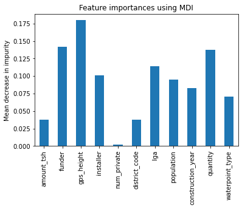

```python
#importancias del bosque_variancethreshold
importances = clf_prim.feature_importances_
std = np.std([clf_prim.feature_importances_ for tree in clf_prim.estimators_], axis=0)

forest_importances = pd.Series(importances, index = feature_names)

fig, ax = plt.subplots()
forest_importances.plot.bar(yerr=std, ax=ax)
ax.set_title("Feature importances using MDI")
ax.set_ylabel("Mean decrease in impurity")
#fig.tight_layout()
```

```python
#importancias por permutación del bosque_variancethreshold
start_time = time.time()
result = permutation_importance(clf_prim, x, y, n_repeats=10, random_state=0)
elapsed_time = time.time() - start_time
print(f"Elapsed time to compute the importances: {elapsed_time:.3f} seconds")
```

```
Elapsed time to compute the importances: 409.059 seconds
```

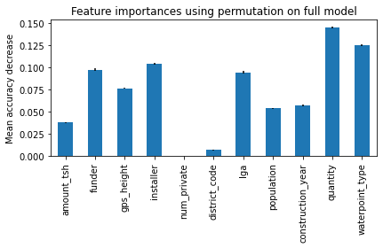

```python
forest_importances = pd.Series(result.importances_mean, index=feature_names)

fig, ax = plt.subplots()
forest_importances.plot.bar(yerr=result.importances_std, ax=ax)
ax.set_title("Feature importances using permutation on full model")
ax.set_ylabel("Mean accuracy decrease")
fig.tight_layout()
plt.show()
```

#### Modelo basado en importancias

```python
#RandomForestClassifier quitando num_private
x_aux = df.drop(labels = ['status_group','id','num_private'], axis = 1, inplace = False)

selector = VarianceThreshold(0.02)
x = selector.fit_transform(x_aux)
selector.get_support(indices = True)
x_features = selector.get_feature_names_out(input_features = x_aux.columns)

x_train, x_test, y_train, y_test = train_test_split(x, y,
                                                    stratify = y, random_state = 42)

clf_numpriv = RandomForestClassifier(
                class_weight = 'balanced',
                random_state = 1,
                n_estimators = 500,
                criterion = 'entropy',
                max_features=None
                                ).fit(x_train, y_train)
y_pred = clf_numpriv.predict(x_test)
metricas(y_test, y_pred, clf_numpriv, x_test)
```

```
matriz de confusión
[[6567  831  667]
 [1082 4322  302]
 [ 415  159  505]]
accuracy
0.7672727272727272
precision
0.7798017073134359
recall
0.7672727272727272
balanced accuracy
0.6799111314800149
f1
0.77244625339529
AUC
0.8661767842410201
MCC
0.5855195441015458
```

```python
#RandomForestClassifier sacando num_private y district_code
x_aux = df.drop(labels = ['status_group','id','num_private', 'district_code'], axis = 1, inplace = False)

selector = VarianceThreshold(0.02)
x = selector.fit_transform(x_aux)
selector.get_support(indices = True)
x_features = selector.get_feature_names_out(input_features = x_aux.columns)

x_train, x_test, y_train, y_test = train_test_split(x, y,
                                                    stratify = y, random_state = 42)

clf_numpriv_distrcode = RandomForestClassifier(
                class_weight = 'balanced',
                random_state = 1,
                n_estimators = 500,
                criterion = 'entropy',
                max_features=None
                                ).fit(x_train, y_train)
y_pred = clf_numpriv_distrcode.predict(x_test)
metricas(y_test, y_pred, clf_numpriv_distrcode, x_test)
```

```
matriz de confusión
[[6575  825  665]
 [1090 4320  296]
 [ 414  162  503]]
accuracy
0.7675420875420875
precision
0.7797388502643973
recall
0.7675420875420875
balanced accuracy
0.6795070861893479
f1
0.7725696444764836
AUC
0.8657097733431321
MCC
0.5857131133319231
```

#### SelectFromModel, Modelo

```python
x.shape
```

```
(59400, 9)
```

```python
#aplicar SelectFromModel al modelo bosque_variancethreshold
x_aux = df.drop(labels = ['status_group','id'], axis = 1, inplace = False)
y = df['status_group']

selector = VarianceThreshold(0.02)
x = selector.fit_transform(x_aux)

model = SelectFromModel(clf_prim, prefit=True)
x_new = model.transform(x)
x_new.shape
```

```
(59400, 6)
```

```python
x_new_features = model.get_feature_names_out(input_features = feature_names)
x_new_features
```

```
array(['funder', 'gps_height', 'installer', 'lga', 'population',
       'quantity'], dtype=object)
```

```python
x_new_train, x_new_test, y_train, y_test = train_test_split(x_new, y,
                                                    stratify = y, random_state = 42)
```

```python
#bosque basado en SelectFromModel
clf_new = RandomForestClassifier(
                class_weight = 'balanced',
                random_state = 1,
                n_estimators = 500,
                criterion = 'entropy',
                max_features=None
                                ).fit(x_new_train, y_train)
y_pred = clf_new.predict(x_new_test)
metricas(y_test, y_pred, clf_new, x_new_test)
```

```
matriz de confusión
[[6187 1167  711]
 [1286 4066  354]
 [ 418  193  468]]
accuracy
0.7219528619528619
precision
0.735935799144706
recall
0.7219528619528619
balanced accuracy
0.6378200523156737
f1
0.7279054230506301
AUC
0.8349054581747887
MCC
0.5073139777399287
```

```python
#predicción
prediccion = clf_new.predict(test_set[x_new_features])
prediccion = pd.DataFrame(prediccion, index = test_set['id'], columns = ['status_group'])

r = {'status_group':{1:'functional', 2:'non functional', 3:'functional needs repair'}}
prediccion.replace(to_replace = r, inplace = True)
prediccion.to_csv('prediccion_sfm.csv')
prediccion.head()
```

| id | status_group |
| --- | --- |
| 50785 | functional |
| 51630 | functional needs repair |
| 17168 | functional |
| 45559 | non functional |
| 49871 | functional |

```python
Image(url="clf_new.png", width=300, height=300)
```

[figure not shown]

#### SequentialFeatureSelection, Modelo y Predicción

```python
x_aux = df.drop(labels = ['status_group','id'], axis = 1, inplace = False)
y = df['status_group']

selector = VarianceThreshold(0.02)
x = selector.fit_transform(x_aux)
x.shape
```

```
(59400, 11)
```

```python
x_train, x_test, y_train, y_test = train_test_split(x, y,
                                                    stratify = y, random_state = 42)
```

```python
#aplicar SequentialFeatureSelection forward
start_time = time.time()
clf_sfsf = RandomForestClassifier(
                class_weight = 'balanced',
                random_state = 1,
                n_estimators = 100,
                criterion = 'entropy',
                max_features=None
                                )
sfsf = SequentialFeatureSelector(clf_sfsf, n_features_to_select=0.9999, direction = 'forward')
sfsf.fit(x_train, y_train)
elapsed_time = time.time() - start_time
print(f"Elapsed time to compute the importances: {elapsed_time:.3f} seconds")
```

```
Elapsed time to compute the importances: 883.289 seconds
```

```python
sfsf.transform(x).shape
```

```
(59400, 10)
```

```python
sfsf.get_feature_names_out(input_features=feature_names)
```

```
array(['amount_tsh', 'funder', 'gps_height', 'installer', 'num_private',
       'lga', 'population', 'construction_year', 'quantity',
       'waterpoint_type'], dtype=object)
```

```python
#aplicar SequentialFeatureSelection backwards
start_time = time.time()
clf_sfsb = RandomForestClassifier(
                class_weight = 'balanced',
                random_state = 1,
                n_estimators = 100,
                criterion = 'entropy',
                max_features=None
                                )
sfsb = SequentialFeatureSelector(clf_sfsb, n_features_to_select=0.9999, direction = 'backward')
sfsb.fit(x_train, y_train)
elapsed_time = time.time() - start_time
print(f"Elapsed time to compute the importances: {elapsed_time:.3f} seconds")
```

```
Elapsed time to compute the importances: 442.967 seconds
```

```python
sfsb.transform(x).shape
```

```
(59400, 10)
```

```python
sfsb_list = sfsb.get_feature_names_out(input_features=feature_names)
sfsb_list
```

```
array(['amount_tsh', 'funder', 'gps_height', 'installer', 'num_private',
       'lga', 'population', 'construction_year', 'quantity',
       'waterpoint_type'], dtype=object)
```

```python
#bosque con variables del SFS backward / forward
x_aux = df[sfsb_list]
y = df['status_group']

selector = VarianceThreshold(0.02)
x = selector.fit_transform(x_aux)
selector.get_support(indices = True)
x_features = selector.get_feature_names_out(input_features = x_aux.columns)

x_train, x_test, y_train, y_test = train_test_split(x, y,
                                                    stratify = y, random_state = 42)

clf = RandomForestClassifier(
                class_weight = 'balanced',
                random_state = 1,
                n_estimators = 500,
                criterion = 'entropy',
                max_features=None
                                ).fit(x_train, y_train)
y_pred = clf.predict(x_test)
metricas(y_test, y_pred, clf, x_test)
```

```
matriz de confusión
[[6582  825  658]
 [1083 4325  298]
 [ 411  164  504]]
accuracy
0.7684175084175084
precision
0.7804414589380915
recall
0.7684175084175084
balanced accuracy
0.6803974203809471
f1
0.7733826382975818
AUC
0.8659608787475287
MCC
0.5872189588682172
```

```python
#predicción
prediccion = clf.predict(test_set[sfsb_list])
prediccion = pd.DataFrame(prediccion, index = test_set['id'], columns = ['status_group'])

r = {'status_group':{1:'functional', 2:'non functional', 3:'functional needs repair'}}
prediccion.replace(to_replace = r, inplace = True)
prediccion.to_csv('prediccion.csv')
prediccion.head()
```

| id | status_group |
| --- | --- |
| 50785 | non functional |
| 51630 | functional |
| 17168 | functional |
| 45559 | non functional |
| 49871 | functional |

```python
Image(url="clf_prediccion.png", width=300, height=300)
```

[figure not shown]

#### Bagging y Predicción

```python
#bagging basado en las variables sfs
x_aux = df[sfsb_list]
y = df['status_group']

selector = VarianceThreshold(0.02)
x = selector.fit_transform(x_aux)
selector.get_support(indices = True)
x_features = selector.get_feature_names_out(input_features = x_aux.columns)

x_train, x_test, y_train, y_test = train_test_split(x, y,
                                                    stratify = y, random_state = 42)

clf_bagging = BaggingClassifier(
                random_state = 1,
                n_estimators = 100,
                max_features = 0.9999
                                ).fit(x_train, y_train)
y_pred = clf_bagging.predict(x_test)
metricas(y_test, y_pred, clf_bagging, x_test)
```

```
matriz de confusión
[[7127  742  196]
 [1286 4344   76]
 [ 609  195  275]]
accuracy
0.790976430976431
precision
0.7816203403917034
recall
0.790976430976431
balanced accuracy
0.6332881617513771
f1
0.7814710411621401
AUC
0.8669617726754747
MCC
0.6104070331676476
```

```python
test_set.info()
```

```
<class 'pandas.core.frame.DataFrame'>
RangeIndex: 14850 entries, 0 to 14849
Data columns (total 25 columns):
 #   Column                 Non-Null Count  Dtype
---  ------                 --------------  -----
 0   id                     14850 non-null  int64
 1   amount_tsh             14850 non-null  float64
 2   funder                 14850 non-null  float64
 3   gps_height             14850 non-null  int64
 4   installer              14850 non-null  float64
 5   num_private            14850 non-null  int64
 6   basin                  14850 non-null  float64
 7   region                 14850 non-null  float64
 8   district_code          14850 non-null  int64
 9   lga                    14850 non-null  float64
```

[output cut: 17 more lines]

```python
#prediccion

prediccion_bagging = clf_bagging.predict(test_set[sfsb_list])
prediccion_bagging = pd.DataFrame(prediccion_bagging, index = test_set['id'], columns = ['status_group'])

r = {'status_group':{1:'functional', 2:'non functional', 3:'functional needs repair'}}
prediccion_bagging.replace(to_replace = r, inplace = True)
prediccion_bagging.to_csv('prediccion_bagging.csv')
prediccion_bagging.head()
```

| id | status_group |
| --- | --- |
| 50785 | functional |
| 51630 | functional |
| 17168 | functional |
| 45559 | non functional |
| 49871 | functional |

```python
Image(url="clf_bagging.jpeg", width=300, height=300)
```

[figure not shown]

#### Creación de un modelo con dummy variables

```python
#armar randomforrest con las variables ya elegidas con el sfs, haciendolas dummy
training_values = pd.read_csv("Pump_it_Up_Data_Mining_the_Water_Table_-_Training_set_values.csv")
df_dm = training_values[sfsb_list].copy()
df_dm.fillna('missing_values', inplace = True)
df_dm = pd.get_dummies(df_dm)

training_labels = pd.read_csv("Pump_it_Up_Data_Mining_the_Water_Table_-_Training_set_labels.csv")
r = {'functional':1, 'non functional':2, 'functional needs repair':3}
training_labels['status_group'].replace(to_replace = r, inplace = True)

test_set = pd.read_csv("Pump_it_Up_Data_Mining_the_Water_Table_-_Test_set_values.csv")
test_set_dm = test_set[sfsb_list].copy()
test_set_dm.fillna('missing_values', inplace = True)
test_set_dm = pd.get_dummies(test_set_dm)

df_dm_columns = df_dm.columns.tolist()
test_set_dm_columns = test_set_dm.columns.tolist()
common_dummies = [value for value in df_dm_columns if value in test_set_dm_columns]
```

```python
len(test_set_dm.columns), len(df_dm_columns), len(common_dummies)
```

```
(2215, 4186, 1707)
```

```python
x_train, x_test, y_train, y_test = train_test_split(df_dm[common_dummies], training_labels['status_group']
                                                    #stratify = training_labels
                                                    , random_state = 42)
```

```python
clf_dm = RandomForestClassifier(
                class_weight = 'balanced',
                random_state = 1,
                n_estimators = 500,
                criterion = 'entropy',
                max_features=None
                                ).fit(x_train, y_train)
```

```python
test_set_dm.columns
```

```
Index(['amount_tsh', 'gps_height', 'num_private', 'population',
       'construction_year', 'funder_0', 'funder_A/co Germany', 'funder_Aar',
       'funder_Abasia', 'funder_Abd',
       ...
       'quantity_insufficient', 'quantity_seasonal', 'quantity_unknown',
       'waterpoint_type_cattle trough', 'waterpoint_type_communal standpipe',
       'waterpoint_type_communal standpipe multiple', 'waterpoint_type_dam',
       'waterpoint_type_hand pump', 'waterpoint_type_improved spring',
       'waterpoint_type_other'],
      dtype='object', length=2215)
```

```python
y_pred = clf_dm.predict(x_test)
metricas(y_test, y_pred, clf_dm, x_test)
```

```
matriz de confusión
[[6534  876  688]
 [1143 4201  334]
 [ 427  149  498]]
accuracy
0.7564309764309765
precision
0.7707330515376462
recall
0.7564309764309765
balanced accuracy
0.6701420794793087
f1
0.7622289058280454
AUC
0.8579107499194337
MCC
0.5663869011443036
```

```python
#predicción
prediccion_dm = clf_dm.predict(test_set_dm[common_dummies])
prediccion_dm = pd.DataFrame(prediccion_dm, index = test_set['id'], columns = ['status_group'])

r = {'status_group':{1:'functional', 2:'non functional', 3:'functional needs repair'}}
prediccion_dm.replace(to_replace = r, inplace = True)
prediccion_dm.to_csv('prediccion_dm.csv')
prediccion_dm.head()
```

| id | status_group |
| --- | --- |
| 50785 | non functional |
| 51630 | functional |
| 17168 | functional |
| 45559 | non functional |
| 49871 | functional |

```python
Image(url="clf_dm.png", width=300, height=300)
```

[figure not shown]

```python
end = perf_counter()
performance = end - start
print("Tiempo total de ejecución:",round(performance/60),"minutos.")
```

```
Tiempo total de ejecución: 44 minutos.
```

# Aux

A continuación se dejan sólo a modo de referencia celdas de código en forma de comentario. Las mismas fueron utilizadas durante el desarrollo del trabajo.

# RandomForestClassifier quitando num_private

x_aux = df.drop(labels = ['status_group','id','num_private'], axis = 1, inplace = False)

selector = VarianceThreshold(0.02) x = selector.fit_transform(x_aux) selector.get_support(indices = True) x_features = selector.get_feature_names_out(input_features = x_aux.columns)

x_train, x_test, y_train, y_test = train_test_split(x, y, stratify = y, random_state = 42)

clf_numpriv = RandomForestClassifier( class_weight = 'balanced', random_state = 1, n_estimators = 500, criterion = 'entropy', max_features=None ).fit(x_train, y_train) y_pred = clf.predict(x_test) metricas(y_test, y_pred)

x_train, x_test, y_train, y_test = train_test_split(x, y, stratify = y, random_state = 42)

clf_numpriv = RandomForestClassifier( class_weight = 'balanced', random_state = 1, n_estimators = 500, criterion = 'entropy', max_features=None ).fit(x_train, y_train) y_pred = clf.predict(x_test) metricas(y_test, y_pred)

forest_importances = pd.Series(importances, index = feature_names)

fig, ax = plt.subplots() forest_importances.plot.bar(yerr=std, ax=ax) ax.set_title("Feature importances using MDI") ax.set_ylabel("Mean decrease in impurity")

# RandomForestClassifier sacando num_private y district_code

x_aux = df.drop(labels = ['status_group','id','num_private', 'district_code'], axis = 1, inplace = False)

selector = VarianceThreshold(0.02) x = selector.fit_transform(x_aux) selector.get_support(indices = True) x_features = selector.get_feature_names_out(input_features = x_aux.columns)

x_train, x_test, y_train, y_test = train_test_split(x, y, stratify = y, random_state = 42)

clf_numpriv_distrcode = RandomForestClassifier( class_weight = 'balanced', random_state = 1, n_estimators = 500, criterion = 'entropy', max_features=None ).fit(x_train, y_train) y_pred = clf.predict(x_test) metricas(y_test, y_pred)

x_train, x_test, y_train, y_test = train_test_split(x, y, stratify = y, random_state = 42)

clf_numpriv = RandomForestClassifier( class_weight = 'balanced', random_state = 1, n_estimators = 500, criterion = 'entropy', max_features=None ).fit(x_train, y_train) y_pred = clf.predict(x_test) metricas(y_test, y_pred)

forest_importances = pd.Series(importances, index = feature_names)

fig, ax = plt.subplots() forest_importances.plot.bar(yerr=std, ax=ax) ax.set_title("Feature importances using MDI") ax.set_ylabel("Mean decrease in impurity")

clf = DecisionTreeClassifier(class_weight = 'balanced').fit(x_train, y_train) y_pred = clf.predict(x_test) metricas(y_test, y_pred)

clf = LogisticRegression() clf.fit(x_train, y_train) y_pred = clf.predict(x_test) metricas(y_test, y_pred)

results = cross_val_score(estimator=clf, X=x_train, y=y_train, cv=5)

results.mean()

results.var()

results.std()

clf = BaggingClassifier( random_state = 1, n_estimators = 100 ).fit(x_train, y_train) y_pred = clf.predict(x_test) metricas(y_test, y_pred)

clf = SVC().fit(x_train, y_train) y_pred = clf.predict(x_test) metricas(y_test, y_pred)

clf = naive_bayes.GaussianNB().fit(x_train, y_train) y_pred = clf.predict(x_test) metricas(y_test, y_pred)